# DS 202 - Lab 4: Tidying and Joining

Thursday 10/24/2019 by 10 pm

Jennie Huxford

10/17/2019

## Format for submission

- We will check whether or not your lab results are reproducible - i.e. we will knit your `team.Rmd` file.
- You will also be graded on **style**. Style means is your lab *clear, easy to read, and flows logically*? This lab does **not** need to be in report format but it should be neatly organized with appropriate `R` chunks.
- Each plot at **minimum** must have labels for both axes and a title. If you don’t have these components, you will not get full credit for your answers. Each plot ideally should also come with a description.

## Submission

Your git repo will contain the following files: `team.Rmd` and `team.html` containing the collaborated work.

- Both teammates need to modify `team.Rmd`. `git log team.Rmd` should show commit information from both teammates.
- To submit:
1. Push `team.Rmd` and `team.html` to the owner’s git repo.
2. **Submit both `team.Rmd` and `team.html` to Canvas as well**. In your submission, include:
   - The owner’s GitHub username
   - The partner’s GitHub username
   - Repo name (should be `ds202_lab4`)
- Due date: Thursday Oct. 24 by 10 pm.

## Background

An excerpt of the individual player data of the Cyclone football team is available from Canvas. Dowload the excel file and put the file next to your Rmd files.

Some abbreviations for the column names can be found in the Glossaries sheet in the Excel file.

**References:**

- [Iowa State University Athelete](https://cyclones.com/index.aspx)
- [A Beginner’s Guide to American Football](https://www.youtube.com/watch?v=3t6hM5tRlfA) for the rules of American football.

## Loading Data: Cyclone Football

The Cyclone football data involves multiple Excel sheets and is in a somewhat messy form. The following code loads the Defensive sheet into R. **For this lab, also import the Offensive and the Biography sheets.**

```r
library(readxl)
defense <- read_excel('cyclonesFootball2018.xlsx', sheet='Defensive')
str(defense)
```

```
## Classes 'tbl_df', 'tbl' and 'data.frame':    446 obs. of  11 variables:
##  $ Name             : chr  "Eisworth, Greg" "Eisworth, Greg" "Eisworth, Greg" "Eisworth, Greg" ...
##  $ Opponent_Opponent: chr  "Iowa" "Oklahoma" "Akron" "TCU" ...
##  $ Tackles_Solo     : chr  "3" "6" "7" "6" ...
##  $ Tackles_ASST     : chr  "3" "8" "2" "3" ...
##  $ Tackles_TFL      : chr  "0" "1.0" "1.0" "0" ...
##  $ Tackles_Sack     : chr  "0" "0" "0" "0" ...
##  $ Turnover_FF      : chr  "0" "1" "0" "0" ...
##  $ Turnover_FR      : chr  "0" "0" "0" "0" ...
##  $ Turnover_INT     : chr  "0" "0" "0" "0" ...
##  $ Pass_QBH         : chr  "0" "0" "0" "0" ...
##  $ Pass_PB          : chr  "0" "0" "3" "0" ...
```

## Part one: Cleaning data

The three Excel sheets are loaded into R but they are not useful to us before some cleaning. Manipulate the three imported data frames, so that the cleaned data satisfy the following:

1. The player names and opponent names are factors.

```r
offense$Name <- as.factor(offense$Name)
offense$Opponent_Opponent <- as.factor(offense$Opponent_Opponent)
defense$Name <- as.factor(defense$Name)
defense$Opponent_Opponent <- as.factor(defense$Opponent_Opponent)
bio$Name <- as.factor(bio$Name)
```

2. All offensive and defensive statistics are numerical. The `Weight` column in Biography is also numeric. (Hint: look at `?mutate_at` if you want to save writing some code).

```r
offense <- offense %>% mutate_at(c('Receiving_REC', 'Receiving_TD', 'Receiving_YDS', 'Rushing_ATT', 'Rushing_YDS', 'Rushing_TD', 'Passing_CMP-ATT', 'Passing_YDS', 'Passing_TD', 'Passing_INT'), as.numeric)
defense <- defense %>% mutate_at(c('Tackles_Solo', 'Tackles_ASST', 'Tackles_TFL', 'Tackles_Sack', 'Turnover_FF', 'Turnover_FR', 'Turnover_INT', 'Pass_QBH', 'Pass_PB'), as.numeric)
```

```r
bio <- bio %>% mutate_at(c('Weight'), as.numeric)
```

3. Separate the `Height` column into two columns. Make sure the newly created columns are numeric. Then create one column that represents `Height` (Hint: Use a unit that works well). Drop any irrelavant columns from this process.

```r
bio <- bio %>% separate(Height, into = c("Height (feet)", "Height (inches)")) %>% mutate_at(c('Height (feet)', 'Height (inches)'), as.numeric)
head(bio)
```

```
## # A tibble: 6 x 8
##   Name  Position `Height (feet)` `Height (inches… Weight Class Hometown
##   <fct> <chr>              <dbl>            <dbl>  <dbl> <chr> <chr>
## 1 Aker… Wide Re…               6                0    192 Reds… Cedar R…
## 2 Alle… Tight E…               6                7    240 Reds… Nixa, M…
## 3 Alt,… Offensi…               6                2    290 Reds… Cedar R…
## 4 Ande… Tight E…               6                4    250 Reds… League …
## 5 Assa… Placeki…               6                0    191 Reds… Napervi…
## 6 Aust… Linebac…               5               11    205 Reds… Walnut,…
## # … with 1 more variable: Highschool <chr>
```

```r
bio<- bio %>% unite("Height", c("Height (feet)", "Height (inches)"), sep = "'", remove = TRUE)
```

4. By cleaning the three data frames in R, at the end of this step you should have the following three clean data frames: `defClean`, `offClean`, and `bioClean`. Print the structures of these data frames. **Make sure your data types make sense for each variable.**

```r
defClean <- data.frame(defense)
head(defClean)
```

```
##             Name Opponent_Opponent Tackles_Solo Tackles_ASST Tackles_TFL
## 1 Eisworth, Greg              Iowa            3            3           0
## 2 Eisworth, Greg          Oklahoma            6            8           1
## 3 Eisworth, Greg             Akron            7            2           1
## 4 Eisworth, Greg               TCU            6            3           0
## 5 Eisworth, Greg    Oklahoma State            3            0           1
## 6 Eisworth, Greg     West Virginia            5            3           1
##   Tackles_Sack Turnover_FF Turnover_FR Turnover_INT Pass_QBH Pass_PB
## 1            0           0           0            0        0       0
## 2            0           1           0            0        0       0
## 3            0           0           0            0        0       3
## 4            0           0           0            0        0       0
## 5            0           0           0            0        0       0
## 6            1           0           0            0        0       0
```

```r
offClean <- data.frame(offense)
head(offClean)
```

```
##               Name Opponent_Opponent Receiving_REC Receiving_YDS
## 1 Jones, Deshaunte              Iowa             1            31
## 2 Jones, Deshaunte          Oklahoma             9            66
## 3 Jones, Deshaunte             Akron             6            39
## 4 Jones, Deshaunte               TCU             3            23
## 5 Jones, Deshaunte    Oklahoma State             6            37
## 6 Jones, Deshaunte     West Virginia             1            32
##   Receiving_TD Rushing_ATT Rushing_YDS Rushing_TD Passing_CMP.ATT
## 1            0          NA          NA         NA              NA
## 2            0          NA          NA         NA              NA
## 3            0          NA          NA         NA              NA
## 4            0          NA          NA         NA              NA
## 5            1          NA          NA         NA              NA
## 6            1          NA          NA         NA              NA
##   Passing_YDS Passing_TD Passing_INT
## 1          NA         NA          NA
## 2          NA         NA          NA
## 3          NA         NA          NA
## 4          NA         NA          NA
## 5          NA         NA          NA
## 6          NA         NA          NA
```

```r
bioClean <- data.frame(bio)
head(bioClean)
```

```
##               Name       Position Height Weight              Class
## 1    Akers, Landen  Wide Receiver    6'0    192 Redshirt Sophomore
## 2     Allen, Chase      Tight End    6'7    240 Redshirt Sophomore
## 3       Alt, Gerry Offensive Line    6'2    290  Redshirt Freshman
## 4   Anderson, Cole      Tight End    6'4    250    Redshirt Senior
## 5 Assalley, Connor    Placekicker    6'0    191 Redshirt Sophomore
## 6    Austin, Aaron     Linebacker   5'11    205 Redshirt Sophomore
##             Hometown  Highschool
## 1 Cedar Rapids, Iowa  Washington
## 2          Nixa, Mo.        Nixa
## 3 Cedar Rapids, Iowa  Washington
## 4 League City, Texas Clear Falls
## 5   Naperville, Ill.     Central
## 6     Walnut, Calif. Bishop Amat
```

## Part two: Tidying (A)

For the following questions, work on the cleaned data frames `defClean`, `offClean`, and `bioClean`.

1. Reformat the `defClean` data frame into a tidy format using `gather`. The type of statistic (Tackles_Solo, Tackles_ASST, etc) is added as a **new key column named `Statistic`.**

```r
defClean<- defClean %>% gather(key = Statistic , value = value, 3:11)
head(defClean)
```

```
##             Name Opponent_Opponent    Statistic value
## 1 Eisworth, Greg              Iowa Tackles_Solo     3
## 2 Eisworth, Greg          Oklahoma Tackles_Solo     6
## 3 Eisworth, Greg             Akron Tackles_Solo     7
## 4 Eisworth, Greg               TCU Tackles_Solo     6
## 5 Eisworth, Greg    Oklahoma State Tackles_Solo     3
## 6 Eisworth, Greg     West Virginia Tackles_Solo     5
```

2. Create a histogram for each defensive statistic (make sure to explore different binwidths). Use `facet_wrap` to draw all histograms in a single plot. What defensive skills are rare?

```r
library(ggplot2)
```

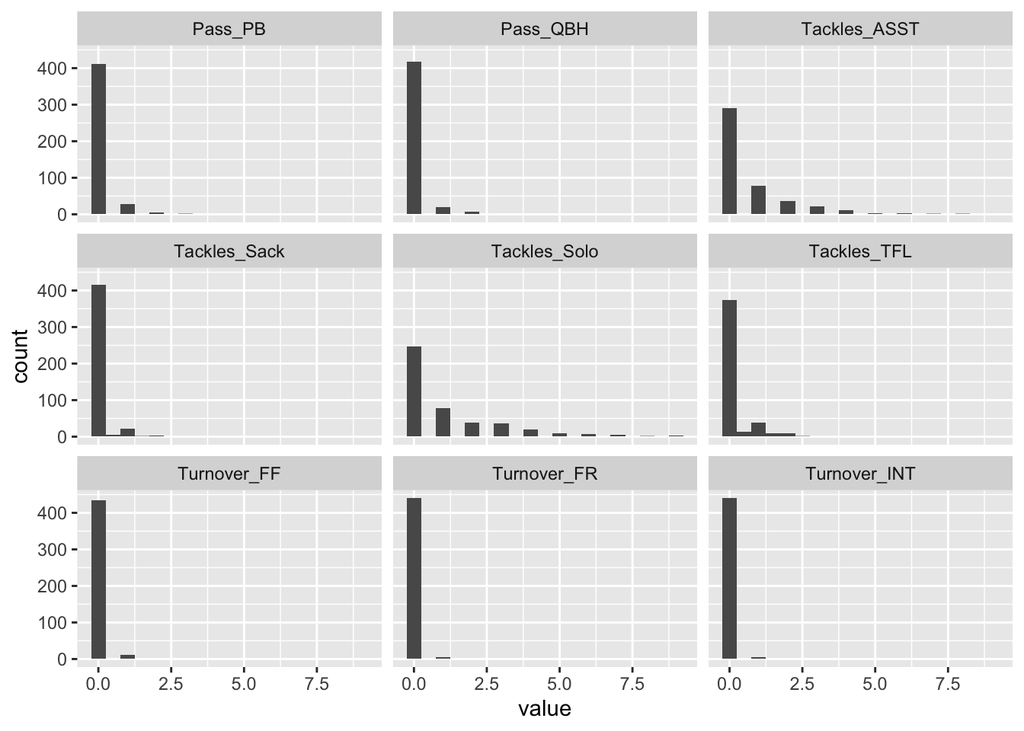

```r
ggplot(defClean, aes(value)) + geom_histogram(binwidth = 0.5) + facet_wrap(~Statistic)
```

The rare defensive skills are turnovers from fumble returns, forced fumbles and interceptions, along with sacks. These defensive skills appear to have a lot fewer occurances than the 5 skills based on the graphs above.

3. Did ISU have better defense against West Virginia or Kansas State? Answer this question by creating a scatterplot with x-axis being the number of solo tackles (by each player) against West Virginia, and y-axis being that against Kansas State. A large number of solo tackles indicates good defense.

   (**Hint**: From step 1 we have gathered our `defClean` into 4 columns.  
   Now we only want to focus on solo tackles (hint…`filter`). Look at your data structure. What form do we need our data to have in order to easily answer this question? (hint…`spread`)).

```r
solotackles <- defClean %>% filter(Statistic == "Tackles_Solo", Opponent_Opponent %in% c("Kansas State", "West Virginia"))
solotackles <- solotackles %>% spread(key = Opponent_Opponent, value = value)
na.omit(solotackles)
```

```
##                  Name    Statistic Kansas State West Virginia
## 1       Akers, Landen Tackles_Solo            1             0
## 3  Bailey, Cordarrius Tackles_Solo            0             0
## 4      Bailey, JaQuan Tackles_Solo            0             2
## 5     Benton, Spencer Tackles_Solo            0             1
## 6      Butler, Hakeem Tackles_Solo            0             1
## 7      Eisworth, Greg Tackles_Solo            3             5
## 8      Francis, Chris Tackles_Solo            0             0
## 9     Grant, Jatairis Tackles_Solo            1             0
## 11     Harvey, Willie Tackles_Solo            7             1
## 12       Hummel, Jake Tackles_Solo            3             2
## 13  Johnson , Anthony Tackles_Solo            3             1
## 14    Johnson, Jamahl Tackles_Solo            0             2
## 15   Jones, Deshaunte Tackles_Solo            0             0
## 16      Knipfel, Josh Tackles_Solo            0             0
## 17     Kolar, Charlie Tackles_Solo            0             0
## 18      Lang, Johnnie Tackles_Solo            0             0
## 19          Leo, Matt Tackles_Solo            0             0
## 20     Lewis, Braxton Tackles_Solo            4             4
## 23    Milton, Tarique Tackles_Solo            0             0
## 24   Northrup, Reggan Tackles_Solo            1             0
## 26       Peavy, Brian Tackles_Solo            9             2
## 27     Petersen, Zach Tackles_Solo            0             0
## 29         Rose, Mike Tackles_Solo            2             1
## 30     Ruth, De'Monte Tackles_Solo            0             0
## 31     Soehner, Dylan Tackles_Solo            2             0
## 33  Uwazurike, Eyioma Tackles_Solo            3             0
## 34      Vance, O'Rien Tackles_Solo            1             0
## 36      Wirtel, Steve Tackles_Solo            0             0
```

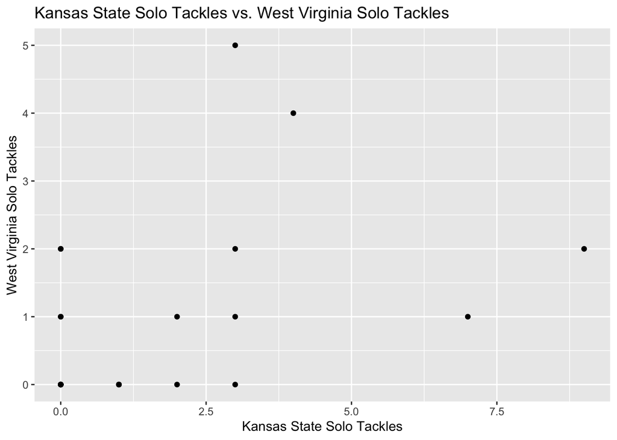

```r
solotackles$ks <- solotackles$`Kansas State`
solotackles$wv <- solotackles$`West Virginia`
ggplot(solotackles, aes(ks, wv)) + geom_point() + ggtitle("Kansas State Solo Tackles vs. West Virginia Solo Tackles") +
  xlab("Kansas State Solo Tackles") +
  ylab("West Virginia Solo Tackles")
```

## Part two: Tidying (B)

Now let’s turn our attention to the player biography `bioClean`.

1. Separate the `Hometown` column into two columns, namely the city and the state. Print the first few rows of these two columns. (Hint: look at the `sep=` argument of `separate`)

```r
bioClean <- bioClean %>% separate(Hometown, into = c("City", "State"), sep = ",")
citystate<- bioClean %>% select(City, State)
head(citystate)
```

```
##           City   State
## 1 Cedar Rapids    Iowa
## 2         Nixa     Mo.
## 3 Cedar Rapids    Iowa
## 4  League City   Texas
## 5   Naperville    Ill.
## 6       Walnut  Calif.
```

2. How many players are there from each state?

```r
table(bioClean$State)
```

```
##
##      Ariz.       Ark.  Australia     Calif.       D.C.       Fla.
##          3          2          2          8          1          8
##        Ga.       Ill.       Iowa       Kan.      Mass.        Md.
##          2          5         44          3          1          1
##      Mich.      Minn.      Miss.        Mo.       Neb.    Nigeria
##          5          2          1          1          1          1
##       Ohio      Okla.        Pa.       S.C.      Texas        Va.
##         10          4          2          2          9          1
##       Wis.
##          4
```

## Part three: Joining data frames

1. Find out where the offensive players are from by joining the offensive data and player biography data appropriately.

```r
offbio <- left_join(offClean, bioClean, by = "Name")
offbio_distinct <- offbio %>% distinct(Name, State) %>% select(Name, State)
table(offbio_distinct$State)
```

```
##
##  Ariz.   Ark.   Fla.   Iowa    Md.    Mo.   Ohio  Okla.  Texas    Va.
##      1      1      2      1      1      1      3      1      1      1
##   Wis.
##      1
```

2. Is there a relationship between the weight of a player and the receiving yards (`Receiving_YDS`)?

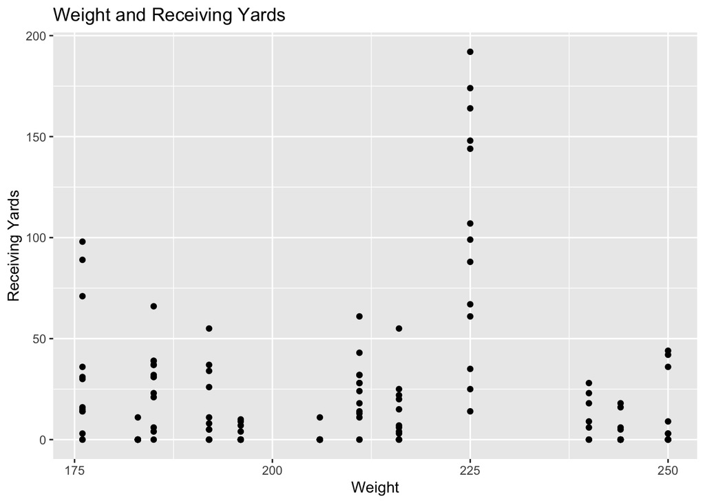

```r
ggplot(offbio, aes(Weight, Receiving_YDS)) + geom_point() + ggtitle("Weight and Receiving Yards") +
  xlab("Weight") +
  ylab("Receiving Yards")
```

Looking at the graph above there does not appear to be an obvious strong relationship between weight of the player and receiving yards. However it does look as if the lower weights tend to have higher recieving yards, except for the player at 225 lbs.

3. Explore more. Raise a question that can be answered only by looking at two or more data frames. Then answer that question.

Is the weight of a player associated with the number of sacks they have?

```r
defbio<- left_join(defClean, bioClean, by = "Name")
sacks <- defbio %>% filter(Statistic == "Tackles_Sack")
```

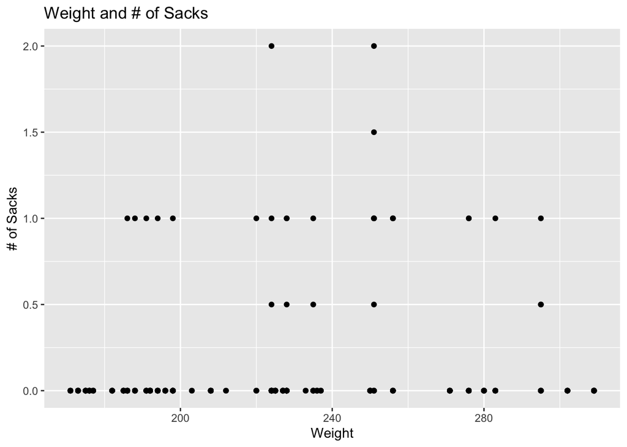

```r
ggplot(sacks, aes(Weight, value)) + geom_point() + ggtitle("Weight and # of Sacks") +
  xlab("Weight") +
  ylab("# of Sacks")
```